# projection pursuit

### $\lambda$ selection for p=40

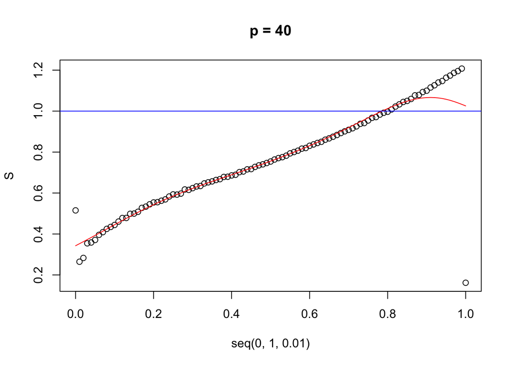

```r
#par(mfrow = c(1, 2))
S(t(df_bw), class, "PDA", 2)
title("p = 40")
```

```r
#S(t(df), class, "PDA", 2)
#title("Entire dataset")
```

```r
ind = sample(1:72, 27, replace=FALSE)
test = df_bw[, ind]
train = df_bw[, -ind]
cls_test = class[ind]
cls_train = class[-ind]
```

```r
plot_test_train = function(proj.data.test, proj.data.train, cls_test, cls_train){
  lim = c(min(min(proj.data.test), min(proj.data.train)),
          max(max(proj.data.test), max(proj.data.train)))
  plot(proj.data.test[,1][cls_test == "AML"], proj.data.test[,2][cls_test == "AML"], pch = 1, xlim = lim, ylim= lim, xlab = "", ylab = "", col = "darkgrey")
  points(proj.data.test[,1][cls_test == "ALL B-cell"], proj.data.test[,2][cls_test == "ALL B-cell"], pch = 2, col = "darkgrey")
  points(proj.data.test[,1][cls_test == "ALL T-cell"], proj.data.test[,2][cls_test == "ALL T-cell"], pch = 3, col = "darkgrey")
  text(proj.data.train[,1], proj.data.train[,2], as.numeric(factor(cls_train)), cex=1)
}
```

### p=40

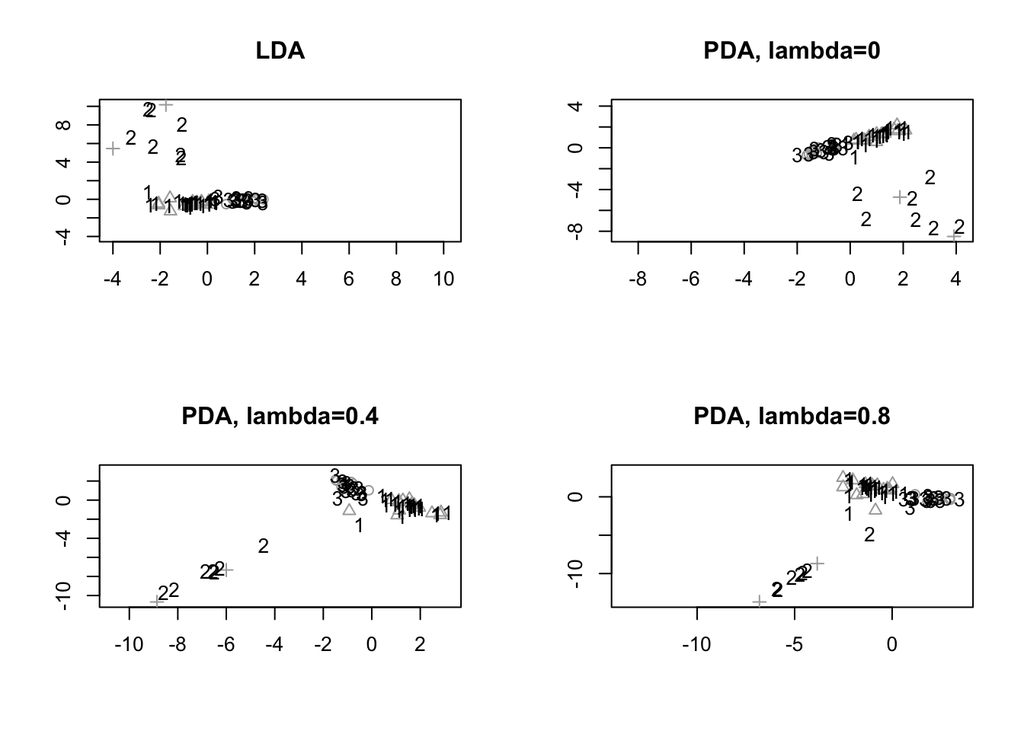

```r
par(mfrow = c(2, 2))

PP.opt = PP.optimize.anneal("LDA",2,t(train),cls_train)
proj.data.test = as.matrix(t(test))%*%PP.opt$proj.best
proj.data.train = as.matrix(t(train))%*%PP.opt$proj.best
plot_test_train(proj.data.test, proj.data.train, cls_test, cls_train)
title("LDA")

PP.opt = PP.optimize.anneal("PDA",2,t(train),cls_train,lambda = 0)
proj.data.test = as.matrix(t(test))%*%PP.opt$proj.best
proj.data.train = as.matrix(t(train))%*%PP.opt$proj.best
plot_test_train(proj.data.test, proj.data.train, cls_test, cls_train)
title("PDA, lambda=0")

PP.opt = PP.optimize.anneal("PDA",2,t(train),cls_train,lambda = 0.4)
proj.data.test = as.matrix(t(test))%*%PP.opt$proj.best
proj.data.train = as.matrix(t(train))%*%PP.opt$proj.best
plot_test_train(proj.data.test, proj.data.train, cls_test, cls_train)
title("PDA, lambda=0.4")

PP.opt = PP.optimize.anneal("PDA",2,t(train),cls_train,lambda = 0.8)
proj.data.test = as.matrix(t(test))%*%PP.opt$proj.best
proj.data.train = as.matrix(t(train))%*%PP.opt$proj.best
plot_test_train(proj.data.test, proj.data.train, cls_test, cls_train)
title("PDA, lambda=0.8")
```

### p=3571

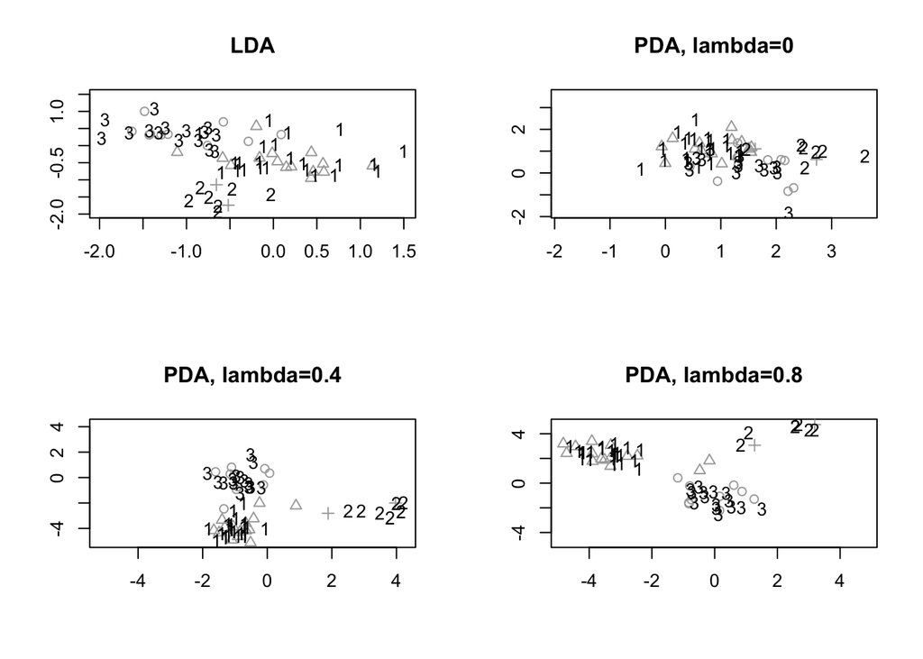

```r
test = df[, ind]
train = df[, -ind]

par(mfrow = c(2, 2))

PP.opt = PP.optimize.anneal("LDA",2,t(train),cls_train)
proj.data.test = as.matrix(t(test))%*%PP.opt$proj.best
proj.data.train = as.matrix(t(train))%*%PP.opt$proj.best
plot_test_train(proj.data.test, proj.data.train, cls_test, cls_train)
title("LDA")

PP.opt = PP.optimize.anneal("PDA",2,t(train),cls_train,lambda = 0)
proj.data.test = as.matrix(t(test))%*%PP.opt$proj.best
proj.data.train = as.matrix(t(train))%*%PP.opt$proj.best
plot_test_train(proj.data.test, proj.data.train, cls_test, cls_train)
title("PDA, lambda=0")

PP.opt = PP.optimize.anneal("PDA",2,t(train),cls_train,lambda = 0.4)
proj.data.test = as.matrix(t(test))%*%PP.opt$proj.best
proj.data.train = as.matrix(t(train))%*%PP.opt$proj.best
plot_test_train(proj.data.test, proj.data.train, cls_test, cls_train)
title("PDA, lambda=0.4")

PP.opt = PP.optimize.anneal("PDA",2,t(train),cls_train,lambda = 0.8)
proj.data.test = as.matrix(t(test))%*%PP.opt$proj.best
proj.data.train = as.matrix(t(train))%*%PP.opt$proj.best
plot_test_train(proj.data.test, proj.data.train, cls_test, cls_train)
title("PDA, lambda=0.8")
```

### p=3571

- compare 1-dimensional projection to 2-dimensional projection

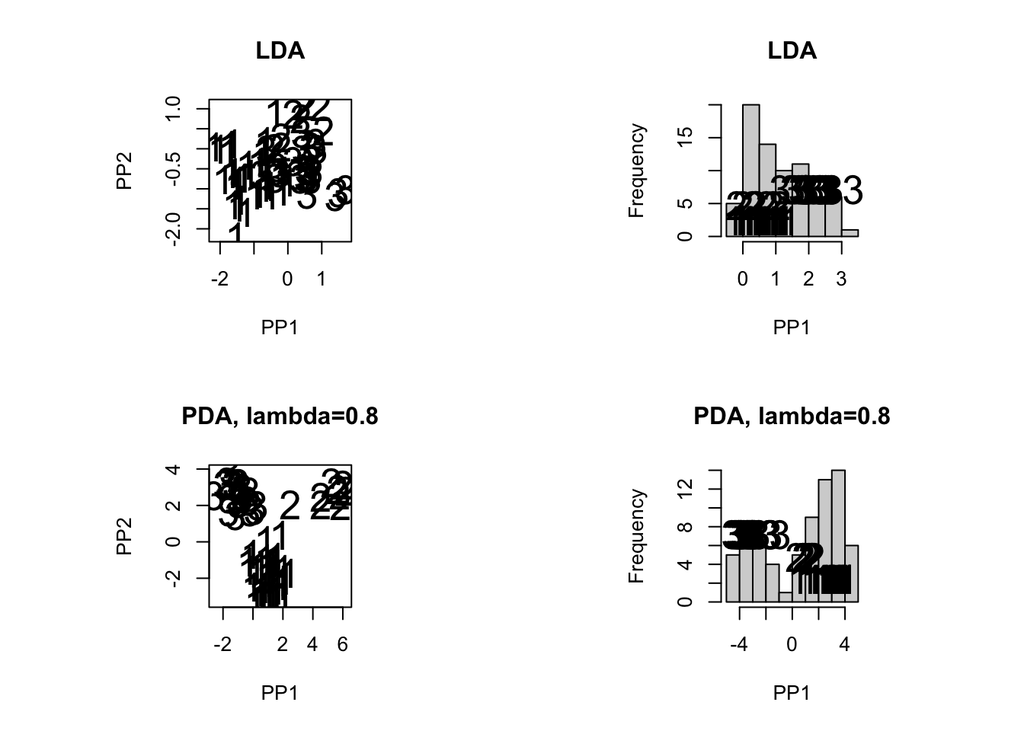

```r
par(mfrow = c(2, 2))

PP.opt = PP.optimize.anneal("LDA",2,t(df),class)
PP.optimize.plot(PP.opt,t(df),class)
title("LDA")

PP.opt = PP.optimize.anneal("LDA",1,t(df),class)
PP.optimize.plot(PP.opt,t(df),class)
title("LDA")

PP.opt = PP.optimize.anneal("PDA",2,t(df),class,lambda = 0.8)
PP.optimize.plot(PP.opt,t(df),class)
title("PDA, lambda=0.8")

PP.opt = PP.optimize.anneal("PDA",1,t(df),class,lambda = 0.8)
PP.optimize.plot(PP.opt,t(df),class)
title("PDA, lambda=0.8")
```

### prcomp

- singular value decomposition
- cannot apply to big p, small n

```r
# pp = PP_Optimizer(data = t(train), class = cls_train, findex = "lda", optmethod = "GTSA", dimproj = 2, sphere=FALSE)
#
# proj.data.train = as.matrix(t(train)) %*% matrix(c(pp[["vector.opt"]][,1], pp[["vector.opt"]][,2]), ncol = 2)
# proj.data.train = as.matrix(t(test)) %*% matrix(c(pp[["vector.opt"]][,1], pp[["vector.opt"]][,2]), ncol = 2)
#
# plot_test_train(proj.data.test, proj.data.train, cls_test, cls_train)
#
# p1 = pp[["proj.data"]][["Projection 1"]]
# p2 = pp[["proj.data"]][["Projection 2"]]
# plot(p1, p2)
# plot(proj[,1], proj[,2])
# Plot.PP(pp)
#
#
# barplot(height = abs(pp[["vector.opt"]][,1]), names = as.factor(1:40))
# Plot.PP(pp)
```

### Variable selection

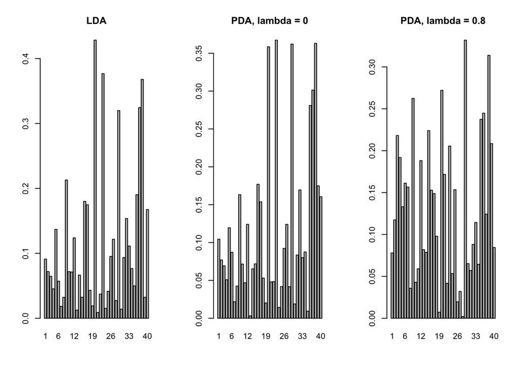

```r
PP.opt.lda = PP.optimize.anneal("LDA",1,t(df_bw),class)
PP.opt.pda0 = PP.optimize.anneal("PDA",1,t(df_bw),class,lambda = 0)
PP.opt.pda = PP.optimize.anneal("PDA",1,t(df_bw),class,lambda = 0.8)
par(mfrow = c(1, 3))
barplot(height = as.numeric(abs(PP.opt.lda[["proj.best"]])), names = as.factor(1:40))
title("LDA")
barplot(height = as.numeric(abs(PP.opt.pda0[["proj.best"]])), names = as.factor(1:40))
title("PDA, lambda = 0")
barplot(height = as.numeric(abs(PP.opt.pda[["proj.best"]])), names = as.factor(1:40))
title("PDA, lambda = 0.8")
```

library(tourr) lda_pp(toy, class)

https://sebastianraschka.com/Articles/2014_python_lda.html

maximum likelihood estimate of covariance matrix #library(rags2ridges) covML #Ys <- scale(df_bw, center = TRUE, scale = FALSE) #cov_ml = crossprod(Ys)/nrow(Ys)

Bayesian estimate #cov = cov(df_bw) #cov = (1-i)*cov_ml+i*diag(cov_ml)

$A^{T}WA$ #x_hat = (diag(cov))^(-1/2)*(df_bw-sum(df_bw)/nrow(df_bw)/ncol(df_bw)) #x_hat = (diag(cov(df_bw)))^(-1/2)*(df_bw-sum(df_bw)/nrow(df_bw)/ncol(df_bw)) #W = withinSS(t(x_hat), class) #S = c(S, t(PP.opt[[“proj.best”]])%*%W%*%PP.opt[[“proj.best”]])